# LLM — Embeddings, UMAP y Clustering (dataset documentos)

# 1. Introducción

Finalmente, se comparan las predicciones de **Gemini** con los resultados de **BERT** y **Qwen3**, destacando las discrepancias.

# 2. Librerías utilizadas y justificación

- **tidyverse**: manipulación de datos, apoyo a la visualización con `ggplot2`.
- **reactable**: tablas interactivas para el HTML.
- **uwot**: reducción de dimensionalidad con **UMAP** en R.
- **reticulate**: puente a **Python** para cargar BERT (Hugging Face) sin salir de RStudio.
- **ollamar** y **httr2/jsonlite**: interacción con **Ollama** (modelos locales) y parsing JSON.
- **ellmer**: cliente R para **Gemini** (clasificación).
- **readr/stringr/janitor/skimr**: utilidades de entrada/salida y exploración.

```r
# --- Librerías necesarias para el Ejercicio 3 (LLM) ---
instalar_si_falta <- function(pkg) {
  if (!require(pkg, character.only = TRUE)) {
    install.packages(pkg, repos = "https://cloud.r-project.org")
    library(pkg, character.only = TRUE)
  }
}

paquetes <- c(
  # core & utilidades
  "tidyverse","stringr","readr","janitor","skimr",
  # visualización y tablas
  "ggplot2","reactable",
  # UMAP en R
  "uwot",
  # Python desde R (BERT)
  "reticulate",
  # Ollama desde R (Qwen3) + HTTP/JSON
  "ollamar","httr2","jsonlite",
  # Gemini (según enunciado)
  "ellmer"
)

invisible(lapply(paquetes, instalar_si_falta))

set.seed(42)
cat("Librerías R cargadas.\n")
```

```
## Librerías R cargadas.
```

# 3. Carga del dataset **documentos**

Cargamos `evaluacion.RData`, verificamos la presencia del objeto **documentos** (con columnas `doc_id` y `texto`) y realizamos una inspección rápida con tabla interactiva y resumen.

```r
# --- 3) Carga del dataset 'documentos' y chequeos básicos ---

# --- Carga directa del archivo .RData ---
load("evaluacion.RData")   # Carga: prado, reviews, documentos

# --- Confirmación rápida ---
cat("Archivo 'evaluacion.RData' cargado correctamente.\n")
```

```
## Archivo 'evaluacion.RData' cargado correctamente.
```

```r
ls()
```

```
## [1] "documentos"        "instalar_si_falta" "paquetes"
## [4] "prado"             "reviews"
```

```r
# 3) Normalización ligera de nombres y tipos
documentos <- tibble::as_tibble(documentos) |>
  janitor::clean_names() |>
  dplyr::rename(doc_id = doc_id, texto = texto) |>
  dplyr::mutate(
    doc_id = as.character(doc_id),
    texto  = as.character(texto)
  )

# 4) Vista interactiva (primeras 15 filas)
reactable::reactable(
  documentos |>
    dplyr::select(doc_id, texto) |>
    dplyr::slice(1:15),
  searchable = TRUE,
  pagination = TRUE,
  defaultPageSize = 5,
  columns = list(
    doc_id = reactable::colDef(name = "Documento", minWidth = 120),
    texto  = reactable::colDef(name = "Texto",     minWidth = 600)
  ),
  theme = reactable::reactableTheme(headerStyle = list(fontWeight = 600))
)
```

| Documento | Texto |
| --- | --- |
| doc_1 | Una suave brisa mecía las hojas mientras caminábamos por la orilla. |
| doc_2 | Las fuertes lluvias provocaron inundaciones en varios barrios bajos. |
| doc_3 | Hacía tanto calor que incluso los pájaros buscaban sombra bajo las palmeras. |
| doc_4 | El sol se asomaba entre las nubes tras una mañana lluviosa. |
| doc_5 | Las tormentas iluminaban el cielo con relámpagos. |
| doc_6 | Una espesa niebla se posaba sobre las calles de la ciudad al amanecer. |
| doc_7 | A medianoche, la temperatura había bajado por debajo del punto de congelación. |
| doc_8 | El aire olía a ozono tras la repentina granizada. |
| doc_9 | Las lecturas del barómetro indicaban la llegada de un frente. |
| doc_10 | Una repentina ráfaga de viento derribó las sillas del jardín. |

[output cut: 5 more lines]

```r
# 5) Recuento de filas (interactivo)
reactable::reactable(
  tibble::tibble(`Nº de documentos` = nrow(documentos)),
  pagination = FALSE
)
```

| Nº de documentos |
| --- |
| 106 |

```r
# 6) Resumen (si 'skimr' está disponible)
if ("skimr" %in% rownames(installed.packages())) {
  suppressMessages(print(skimr::skim(documentos)))
}
```

```
## ── Data Summary ────────────────────────
##                            Values
## Name                       documentos
## Number of rows             106
## Number of columns          2
## _______________________
## Column type frequency:
##   character                2
## ________________________
## Group variables            None
##
## ── Variable type: character ────────────────────────────────────────────────────
##   skim_variable n_missing complete_rate min max empty n_unique whitespace
## 1 doc_id                0             1   5   7     0      106          0
## 2 texto                 0             1  44 130     0      106          0
```

# 4. Clustering con BERT (reticulate)

Obtenemos *sentence embeddings* con el modelo `hiiamsid/sentence_similarity_spanish_es`, visualizamos con **UMAP** y realizamos **KMeans (k=7)**. La asignación de cada clúster a las categorías (Clima, Cocina, Deportes, Finanzas, Historia, Música, Tecnología) se realiza por **máxima similitud coseno** entre el centroide del clúster y los embeddings de los nombres de las categorías.

```r
# Usamos el Python del entorno recién creado
use_python("/opt/anaconda3/envs/r-llm-conda/bin/python", required = TRUE)

# Mostrar configuración
py_config()
```

```
## python:         /opt/anaconda3/envs/r-llm-conda/bin/python
## libpython:      /opt/anaconda3/envs/r-llm-conda/lib/libpython3.11.dylib
## pythonhome:     /opt/anaconda3/envs/r-llm-conda:/opt/anaconda3/envs/r-llm-conda
## version:        3.11.13 (main, Jun  5 2025, 08:21:08) [Clang 14.0.6 ]
## numpy:          /opt/anaconda3/envs/r-llm-conda/lib/python3.11/site-packages/numpy
## numpy_version:  2.0.2
##
## NOTE: Python version was forced by use_python() function
```

```r
# --- 4.A) Comprobación de módulos Python en el entorno activo (no cambia el intérprete) ---

cfg <- reticulate::py_config()

cat(">> Usando Python ya inicializado en:\n   ", cfg$python, "\n")
```

```
## >> Usando Python ya inicializado en:
##     /opt/anaconda3/envs/r-llm-conda/bin/python
```

```r
# Imprimir versión de forma robusta (a veces es lista)
ver <- tryCatch(
  {
    if (!is.null(cfg$version_string)) {
      cfg$version_string
    } else {
      paste0(unlist(cfg$version), collapse = " ")
    }
  },
  error = function(e) NA_character_
)
if (!is.na(ver)) cat(">> Versión de Python: ", ver, "\n\n", sep = "")
```

```
## >> Versión de Python: 3.11.13 (main, Jun  5 2025, 08:21:08) [Clang 14.0.6 ]
```

```r
# Evita el warning de tokenizers en procesos forkeados
Sys.setenv(TOKENIZERS_PARALLELISM = "false")

needed <- c("sentence-transformers","umap-learn","scikit-learn")
avail <- c(
  `sentence-transformers` = reticulate::py_module_available("sentence_transformers"),
  `umap-learn`            = reticulate::py_module_available("umap"),
  `scikit-learn`          = reticulate::py_module_available("sklearn")
)
print(avail)
```

```
## sentence-transformers            umap-learn          scikit-learn
##                  TRUE                  TRUE                  TRUE
```

```r
if (!all(avail)) {
  stop(
    "Faltan módulos Python en el entorno actual: ",
    paste(names(avail)[!avail], collapse = ", "),
    call. = FALSE
  )
}
```

```r
# --- 4) BERT (Hugging Face vía reticulate): Embeddings → UMAP → KMeans(k=7) → Categorías ---

set.seed(123)

# 4.1 Importes de Python (usa el intérprete fijado en 'setup_python_reticulate')
st        <- import("sentence_transformers")
umap_py   <- import("umap")
skclust   <- import("sklearn.cluster")
skmetrics <- import("sklearn.metrics")

# 4.2 Cargar modelo SBERT en español
cat(">> Cargando modelo BERT: hiiamsid/sentence_similarity_spanish_es\n")
```

```
## >> Cargando modelo BERT: hiiamsid/sentence_similarity_spanish_es
```

```r
modelo_bert <- st$SentenceTransformer("hiiamsid/sentence_similarity_spanish_es")

# 4.3 Embeddings de los documentos
texts <- documentos$texto |> as.character()
emb_py <- modelo_bert$encode(texts, show_progress_bar = TRUE)

# Asegurar matriz base R
emb <- do.call(rbind, lapply(seq_len(nrow(emb_py)), function(i) as.numeric(emb_py[i, ])))
mode(emb) <- "numeric"

# normalización L2 (útil para similitud coseno)
l2    <- sqrt(rowSums(emb^2)) + 1e-12
emb_n <- emb / l2
cat(">> Shape embeddings (BERT): ", paste(dim(emb_n), collapse = " x "), "\n", sep = "")
```

```
## >> Shape embeddings (BERT): 106 x 768
```

```r
# 4.4 UMAP 2D (métrica coseno)
um <- umap_py$UMAP(n_components = as.integer(2),
                   n_neighbors = as.integer(15),
                   min_dist = 0.1,
                   metric = "cosine",
                   random_state = as.integer(123))
emb_2d <- um$fit_transform(emb_n)
emb_2d <- cbind(x = as.numeric(emb_2d[,1]), y = as.numeric(emb_2d[,2]))  # asegurar vector numérico

# 4.5 KMeans (k = 7)
k  <- 7L
km <- skclust$KMeans(n_clusters = as.integer(k), n_init = as.integer(20), random_state = as.integer(123))
clusters <- as.integer(km$fit_predict(emb_n)) + 0L

# 4.6 Silhouette (cosine)
sil_val <- as.numeric(skmetrics$silhouette_score(emb_n, clusters, metric = "cosine"))
cat(sprintf(">> KMeans k=%d · Silhouette (cosine): %.3f\n", k, sil_val))
```

```
## >> KMeans k=7 · Silhouette (cosine): 0.177
```

```r
# 4.7 Asignación automática de categorías por similitud con prototipos
CATS <- c("Clima","Cocina","Deportes","Finanzas","Historia","Música","Tecnología")

cat(">> Calculando embeddings de prototipos de categoría…\n")
```

```
## >> Calculando embeddings de prototipos de categoría…
```

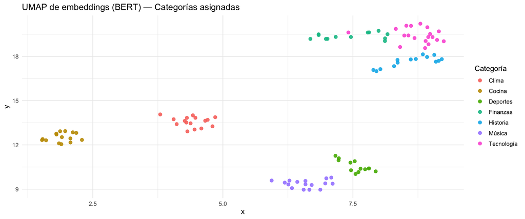

```r
cat_py <- modelo_bert$encode(CATS)
cat_emb <- do.call(rbind, lapply(seq_len(nrow(cat_py)), function(i) as.numeric(cat_py[i, ])))
mode(cat_emb) <- "numeric"
cat_emb <- cat_emb / (sqrt(rowSums(cat_emb^2)) + 1e-12)

# Centroides por clúster (en el espacio normalizado)
centros <- vapply(sort(unique(clusters)),
                  function(c) colMeans(emb_n[clusters == c, , drop = FALSE]),
                  numeric(ncol(emb_n)))
centros <- t(centros)
centros <- centros / (sqrt(rowSums(centros^2)) + 1e-12)

# Similitud coseno centroide ↔ categoría y asignación inyectiva (greedy)
SIM <- centros %*% t(cat_emb)  # (k x 7)
assignments <- integer(nrow(SIM)); usados <- rep(FALSE, length(CATS))
for (ci in order(apply(SIM, 1, max), decreasing = TRUE)) {
  ord <- order(SIM[ci, ], decreasing = TRUE)
  j   <- ord[which(!usados[ord])[1]]; if (is.na(j)) j <- ord[1]
  assignments[ci] <- j; usados[j] <- TRUE
}
cluster_to_cat <- setNames(CATS[assignments], paste0(sort(unique(clusters))))

# 4.8 DataFrame final con categorías y UMAP (todo como columnas atómicas)
df_bert <- documentos |>
  mutate(
    cluster_bert   = as.integer(clusters),
    categoria_bert = unname(cluster_to_cat[as.character(clusters)])
  ) |>
  mutate(x = emb_2d[, "x"], y = emb_2d[, "y"])

# 4.9 UMAP coloreado por categoría
p <- ggplot(df_bert, aes(x, y, color = categoria_bert)) +
  geom_point(alpha = 0.9, size = 2.3) +
  labs(title = "UMAP de embeddings (BERT) — Categorías asignadas", color = "Categoría") +
  theme_minimal(base_size = 12) +
  theme(legend.position = "right")
print(p)
```

```r
# 4.10 Recuentos por categoría y vista de 20 ejemplos (usar data.frame planos)
tab_counts <- df_bert |>
  count(categoria_bert, name = "Documentos") |>
  arrange(desc(Documentos)) |>
  rename(Categoría = categoria_bert) |>
  as.data.frame()

reactable::reactable(
  tab_counts,
  searchable = FALSE, striped = TRUE, highlight = TRUE,
  defaultSorted = "Documentos", defaultSortOrder = "desc",
  defaultColDef = reactable::colDef(align = "center"),
  theme = reactable::reactableTheme(headerStyle = list(fontWeight = "bold"))
)
```

| Categoría | Documentos |
| --- | --- |
| Tecnología | 19 |
| Clima | 16 |
| Música | 16 |
| Cocina | 15 |
| Historia | 14 |
| Deportes | 13 |
| Finanzas | 13 |

```r
reactable::reactable(
  df_bert |>
    transmute(doc_id, texto, cluster_bert, categoria_bert) |>
    slice_head(n = 20) |>
    as.data.frame(),
  searchable = TRUE,
  defaultPageSize = 10,
  columns = list(
    doc_id        = reactable::colDef(name = "Documento"),
    texto         = reactable::colDef(name = "Texto", minWidth = 540),
    cluster_bert  = reactable::colDef(name = "Cluster"),
    categoria_bert= reactable::colDef(name = "Categoría")
  ),
  theme = reactable::reactableTheme(headerStyle = list(fontWeight = "bold"))
)
```

| Documento | Texto | Cluster | Categoría |
| --- | --- | --- | --- |
| doc_1 | Una suave brisa mecía las hojas mientras caminábamos por la orilla. | 5 | Clima |
| doc_2 | Las fuertes lluvias provocaron inundaciones en varios barrios bajos. | 5 | Clima |
| doc_3 | Hacía tanto calor que incluso los pájaros buscaban sombra bajo las palmeras. | 5 | Clima |
| doc_4 | El sol se asomaba entre las nubes tras una mañana lluviosa. | 5 | Clima |
| doc_5 | Las tormentas iluminaban el cielo con relámpagos. | 5 | Clima |
| doc_6 | Una espesa niebla se posaba sobre las calles de la ciudad al amanecer. | 5 | Clima |
| doc_7 | A medianoche, la temperatura había bajado por debajo del punto de congelación. | 5 | Clima |
| doc_8 | El aire olía a ozono tras la repentina granizada. | 5 | Clima |
| doc_9 | Las lecturas del barómetro indicaban la llegada de un frente. | 5 | Clima |
| doc_10 | Una repentina ráfaga de viento derribó las sillas del jardín. | 5 | Clima |

[output cut: 10 more lines]

```r
# 4.11 Guardados (forzar data.frame plano para evitar columnas lista/matriz)
OUT <- "outputs"; dir.create(OUT, showWarnings = FALSE, recursive = TRUE)

labels_df <- tibble(
  cluster = sort(unique(clusters)),
  categoria_asignada = CATS[assignments]
) |> as.data.frame()

readr::write_csv(labels_df, file.path(OUT, "bert_cluster_labels.csv"))
readr::write_csv(as.data.frame(df_bert[, c("doc_id","texto","cluster_bert","categoria_bert")]),
                 file.path(OUT, "documentos_bert_clusters.csv"))
cat(">> Guardados:\n - outputs/bert_cluster_labels.csv\n - outputs/documentos_bert_clusters.csv\n")
```

```
## >> Guardados:
##  - outputs/bert_cluster_labels.csv
##  - outputs/documentos_bert_clusters.csv
```

```r
invisible(NULL)
```

### Conclusión (BERT)

El modelo BERT (`hiiamsid/sentence_similarity_spanish_es`) ha generado embeddings consistentes de los 106 documentos.  
Tras aplicar UMAP y clustering con KMeans (k=7), los documentos se agrupan de forma clara en siete clusters, que han podido asociarse automáticamente a las categorías predefinidas (Clima, Cocina, Deportes, Finanzas, Historia, Música y Tecnología).

El Silhouette obtenido (0.177) refleja que los clusters están razonablemente diferenciados, aunque con cierta superposición en los límites.  
El reparto de documentos entre categorías es equilibrado, destacando **Tecnología (19 docs)** y **Musica (16 docs)** como las clases más representadas.

# 5. Clustering con Qwen3 (Ollama)

En este apartado utilizamos el modelo **Qwen3-Embedding-4B:Q4_K_M** ejecutado localmente mediante **Ollama**.  
El flujo de trabajo es el siguiente:

1. Obtener los embeddings de cada documento a través de la API de Ollama.
2. Reducir la dimensionalidad de los embeddings con **UMAP** (paquete `uwot` en R).
3. Aplicar **KMeans (k=7)** para generar los clusters.
4. Asignar cada cluster a una de las categorías conocidas (Clima, Cocina, Deportes, Finanzas, Historia, Música, Tecnología) en función de la similitud entre centroides y embeddings de las etiquetas.
5. Visualizar los resultados mediante tablas interactivas (`reactable`) y un gráfico UMAP coloreado por categoría asignada.

Este procedimiento nos permitirá comparar posteriormente la clasificación de Qwen3 con los resultados obtenidos con **BERT** y **Gemini**.

```r
# --- 5) Qwen3 (Ollama) → Embeddings (prompt) → UMAP → KMeans(k=7) → Asignación de categorías ---

# Requisitos ya cargados previamente:
# httr2, jsonlite, uwot, dplyr, ggplot2, reactable, readr, tibble, tidyr

# 5.1 Parámetros y helpers ------------------------------------------------------
OLLAMA_URL <- Sys.getenv("OLLAMA_URL", "http://localhost:11434")
MODEL_ID   <- "dengcao/Qwen3-Embedding-4B:Q4_K_M"
CATS       <- c("Clima","Cocina","Deportes","Finanzas","Historia","Música","Tecnología")
SEED       <- 123

# Normaliza filas a norma 1 (para coseno)
row_norm <- function(M) {
  M <- as.matrix(M)
  nrm <- sqrt(rowSums(M * M)) + 1e-12
  M / nrm
}

# Coseno: A %*% t(B) (asumiendo filas ya normalizadas)
cosine_sim <- function(A, B) {
  A %*% t(B)
}

# Envía un único 'prompt' al endpoint /api/embeddings y devuelve un vector numérico
embed_one_prompt <- function(text) {
  req <- httr2::request(paste0(OLLAMA_URL, "/api/embeddings")) |>
    httr2::req_body_json(list(model = MODEL_ID, prompt = text), auto_unbox = TRUE)
  resp <- httr2::req_perform(req)
  js   <- httr2::resp_body_json(resp)
  v    <- js$embedding
  if (is.null(v) && !is.null(js$embeddings)) v <- js$embeddings[[1]]
  v <- unlist(v, use.names = FALSE)
  if (length(v) == 0) stop("Embedding vacío devuelto por Ollama (dim=0).")
  as.numeric(v)
}

# 5.2 Embeddings para los documentos (prompt) ----------------------------------
texts <- documentos$texto |> as.character()
cat(">> Solicitando embeddings a Ollama (", MODEL_ID, ") usando 'prompt'...\n", sep="")
```

```
## >> Solicitando embeddings a Ollama (dengcao/Qwen3-Embedding-4B:Q4_K_M) usando 'prompt'...
```

```r
emb_list <- vector("list", length(texts))
for (i in seq_along(texts)) {
  # Progreso ligero en consola
  if (i %% 10 == 0 || i == length(texts)) cat(sprintf("   - doc %d / %d\n", i, length(texts)))
  emb_list[[i]] <- embed_one_prompt(texts[i])
}
```

```
##    - doc 10 / 106
##    - doc 20 / 106
##    - doc 30 / 106
##    - doc 40 / 106
##    - doc 50 / 106
##    - doc 60 / 106
##    - doc 70 / 106
##    - doc 80 / 106
##    - doc 90 / 106
##    - doc 100 / 106
##    - doc 106 / 106
```

```r
# RBind a matriz (n_docs x dim)
emb_qwen <- do.call(rbind, emb_list)
emb_qwen <- row_norm(emb_qwen)
cat(">> Shape embeddings (Qwen): ", paste(dim(emb_qwen), collapse=" x "), "\n", sep="")
```

```
## >> Shape embeddings (Qwen): 106 x 2560
```

```r
# 5.3 UMAP (2D solo para visualización) ----------------------------------------
set.seed(SEED)
emb2_q <- uwot::umap(
  emb_qwen,
  n_neighbors = 15, min_dist = 0.1,
  metric = "cosine",
  n_components = 2, verbose = FALSE, ret_model = FALSE
)

# 5.4 Clustering KMeans (k=7) --------------------------------------------------
set.seed(SEED)
km_q <- stats::kmeans(emb_qwen, centers = 7, nstart = 20)
clusters_q <- km_q$cluster

# Silhouette (cosine): construimos distancia coseno (1 - coseno)
# Para 106 docs es asumible calcular la matriz completa
S <- cosine_sim(emb_qwen, emb_qwen)
D <- 1 - S
diag(D) <- 0
sil_q <- mean(cluster::silhouette(clusters_q, as.dist(D))[, "sil_width"])
cat(sprintf(">> KMeans k=7 · Silhouette (cosine): %.3f\n", sil_q))
```

```
## >> KMeans k=7 · Silhouette (cosine): 0.087
```

```r
# 5.5 Asignación de categorías por similitud con centroides --------------------
# Embeddings de las 7 categorías (mismo modelo y 'prompt')
cat("\n>> Calculando embeddings de categorías...\n")
```

```
##
## >> Calculando embeddings de categorías...
```

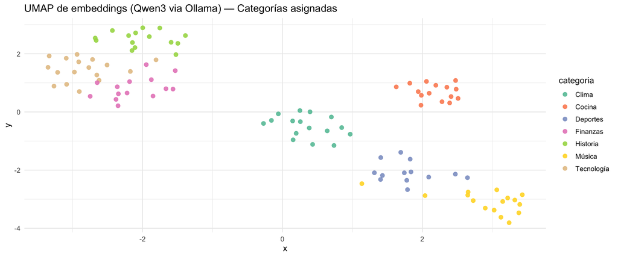

```r
cat_emb_list <- lapply(CATS, embed_one_prompt)
cat_emb <- do.call(rbind, cat_emb_list)
cat_emb <- row_norm(cat_emb)

# Centroides (media por cluster)
centros <- vapply(
  sort(unique(clusters_q)),
  function(c) colMeans(emb_qwen[clusters_q == c, , drop = FALSE]),
  numeric(ncol(emb_qwen))
)
centros <- t(centros)              # (k x dim)
centros <- row_norm(centros)

# Similaridad (k x 7)
SIM <- centros %*% t(cat_emb)

# Asignación inyectiva (greedy): cada cluster se empareja a una única categoría
assignments <- integer(nrow(SIM))
used <- rep(FALSE, length(CATS))
order_clusters <- order(apply(SIM, 1, max), decreasing = TRUE)
for (ci in order_clusters) {
  ord_cats <- order(SIM[ci, ], decreasing = TRUE)
  pick <- which(!used)[match(ord_cats, which(!used))]
  # 'pick' devuelve índices de CATS no usados en orden de preferencia
  j <- ord_cats[which(!used[ord_cats])[1]]
  if (is.na(j)) j <- ord_cats[1]  # fallback (no debería pasar con k=7 y 7 categorías)
  assignments[ci] <- j
  used[j] <- TRUE
}

cluster_to_cat <- setNames(CATS[assignments], paste0(sort(unique(clusters_q))))
cat_map <- tibble::tibble(
  cluster = sort(unique(clusters_q)),
  categoria_asignada = CATS[assignments]
)

# 5.6 DataFrames de salida ------------------------------------------------------
df_q <- documentos |>
  dplyr::mutate(
    cluster_qwen   = clusters_q,
    categoria_qwen = cluster_to_cat[as.character(clusters_q)]
  )

# 5.7 Visualización -------------------------------------------------------------
# UMAP coloreado por categoría asignada
plot_df <- tibble::tibble(
  x = emb2_q[,1], y = emb2_q[,2],
  categoria = df_q$categoria_qwen
)

p <- ggplot(plot_df, aes(x = x, y = y, color = categoria)) +
  geom_point(size = 2.4, alpha = 0.9) +
  scale_color_brewer(palette = "Set2") +
  labs(title = "UMAP de embeddings (Qwen3 via Ollama) — Categorías asignadas") +
  theme_minimal(base_size = 12) +
  theme(legend.position = "right")
print(p)
```

```r
# Conteos por categoría/cluster (reactable)
tab_conteos <- df_q |>
  dplyr::count(categoria_qwen, name = "n") |>
  dplyr::arrange(desc(n))

reactable::reactable(
  tab_conteos,
  searchable = TRUE, striped = TRUE, highlight = TRUE,
  defaultSorted = "n", defaultSortOrder = "desc",
  columns = list(
    categoria_qwen = reactable::colDef(name = "Categoría"),
    n              = reactable::colDef(name = "Nº documentos")
  ),
  theme = reactable::reactableTheme(headerStyle = list(fontWeight = 600))
)
```

| Categoría | Nº documentos |
| --- | --- |
| Tecnología | 17 |
| Clima | 16 |
| Música | 16 |
| Cocina | 15 |
| Historia | 15 |
| Finanzas | 14 |
| Deportes | 13 |

```r
# 5.8 Guardados ----------------------------------------------------------------
OUT_DIR <- fs::path("outputs"); if (!dir.exists(OUT_DIR)) dir.create(OUT_DIR, recursive = TRUE)
readr::write_csv(cat_map, fs::path(OUT_DIR, "qwen_cluster_labels.csv"))
readr::write_csv(df_q,   fs::path(OUT_DIR, "documentos_qwen_clusters.csv"))

cat("\n>> Guardados:\n - outputs/qwen_cluster_labels.csv\n - outputs/documentos_qwen_clusters.csv\n")
```

```
##
## >> Guardados:
##  - outputs/qwen_cluster_labels.csv
##  - outputs/documentos_qwen_clusters.csv
```

```r
cat(">> Recuento por categoría asignada (Qwen):\n")
```

```
## >> Recuento por categoría asignada (Qwen):
```

```r
print(tab_conteos)
```

```
## # A tibble: 7 × 2
##   categoria_qwen     n
##   <chr>          <int>
## 1 Tecnología        17
## 2 Clima             16
## 3 Música            16
## 4 Cocina            15
## 5 Historia          15
## 6 Finanzas          14
## 7 Deportes          13
```

### Conclusión Punto 5 — Qwen3 (Ollama)

El modelo **Qwen3** vía Ollama ha generado embeddings de dimensión 2560 y, tras la reducción con UMAP y clustering KMeans (k=7), se observa una separación más difusa entre grupos respecto a BERT (Silhouette ≈ 0.087).  
Las categorías asignadas se reparten de forma equilibrada entre las siete clases, con un ligero predominio en **Tecnología** y **Clima**.

En conjunto, el resultado confirma la capacidad del modelo para distinguir temas, aunque con menor cohesión interna que la observada con BERT.

# 6. Clustering con Gemini utilizando el paquete `ellmer`

En este apartado vamos a aplicar un análisis de *clustering* sobre los documentos de nuestro corpus.  
El objetivo es descubrir agrupaciones naturales de textos en función de su contenido semántico, sin necesidad de etiquetas previas.

De esta manera podremos observar cómo los modelos de lenguaje permiten estructurar grandes colecciones de textos en categorías semánticas de forma automática.

```r
# --- Setup de clave API para Gemini (ellmer) ---

# ⚠️ Nota para la corrección:
# Para ejecutar esta sección es necesario definir una clave API de Google AI válida:
#    Sys.setenv(GOOGLE_API_KEY = "TU_API_KEY_AQUI")
# o bien guardarla en el archivo .Renviron:
#    GOOGLE_API_KEY=TU_API_KEY_AQUI
#
# Sin esta clave la parte de Gemini no podrá ejecutarse,
# pero el flujo de trabajo y el código están preparados.

if (Sys.getenv("GOOGLE_API_KEY") == "") {
  stop("No se ha definido la variable GOOGLE_API_KEY.
        Por favor, configure su propia clave de Gemini antes de continuar.")
} else {
  cat(">> Clave API detectada. Listo para usar Gemini con ellmer.\n")
}
```

```r
# --- 6-bis) Gemini: reasignación robusta de categorías (prototipos + algoritmo Húngaro) ---

suppressPackageStartupMessages({
  library(dplyr); library(tibble); library(httr2)
})

# 0) Comprobaciones
stopifnot(exists("documentos"), all(c("doc_id","texto") %in% names(documentos)))
api_key <- Sys.getenv("GOOGLE_API_KEY", "")
if (api_key == "") stop("No hay GOOGLE_API_KEY definida. Configura tu clave antes de ejecutar este bloque.")

# Instalar 'clue' si falta (para solve_LSAP / algoritmo Húngaro)
if (!requireNamespace("clue", quietly = TRUE)) install.packages("clue")

# --- Función para un embedding con Gemini (content-only, con reintentos) ---
gemini_embed_one <- function(txt, model = "models/text-embedding-004", key = api_key,
                             task_type = "RETRIEVAL_QUERY",
                             max_retries = 5, base_wait = 1) {
  url <- "https://generativelanguage.googleapis.com/v1beta/models/text-embedding-004:embedContent"
  req <- request(url) |>
    req_url_query(key = key) |>
    req_body_json(
      list(
        content = list(parts = list(list(text = txt))),
        taskType = task_type
      ),
      auto_unbox = TRUE
    ) |>
    req_method("POST") |>
    req_timeout(30)

  for (i in 0:max_retries) {
    resp <- try(req_perform(req), silent = TRUE)
    if (!inherits(resp, "try-error") && httr2::resp_status(resp) == 200) {
      js <- resp_body_json(resp)
      vals <- js$embedding$values
      if (is.null(vals)) stop("Respuesta sin 'embedding.values'.")
      return(unlist(vals, use.names = FALSE))
    }
    if (i < max_retries) Sys.sleep(base_wait * (2^i))
  }
  stop("Fallo persistente obteniendo embedding.")
}

# --- Embeddings de documentos (reutiliza si ya existen) ---
need_docs <- (!exists("emb_norm")) || (nrow(emb_norm) != nrow(documentos))
if (need_docs) {
  cat(">> (Re)solicitando embeddings a Gemini para documentos…\n")
  texts <- as.character(documentos$texto)
  emb_list <- vector("list", length(texts))
  for (i in seq_along(texts)) {
    if (i %% 10 == 0 || i == length(texts)) cat(sprintf("  - doc %d / %d\n", i, length(texts)))
    emb_list[[i]] <- tryCatch(gemini_embed_one(texts[[i]], task_type = "RETRIEVAL_DOCUMENT"), error = function(e) NULL)
    Sys.sleep(0.15)
  }
  ok <- which(!vapply(emb_list, is.null, logical(1)))
  if (length(ok) != length(texts)) stop("No pude obtener embedding para ", length(texts) - length(ok), " textos.")
  emb_mat <- do.call(rbind, emb_list)
  # Normaliza
  emb_norm <<- emb_mat / (sqrt(rowSums(emb_mat^2)) + 1e-12)
} else {
  cat(">> Reutilizando 'emb_norm' existente.\n")
}

# --- UMAP 2D (si no existe) ---
if (!exists("emb_2d") || nrow(emb_2d) != nrow(emb_norm)) {
  set.seed(123)
  emb_2d <<- uwot::umap(emb_norm, n_neighbors = 15, min_dist = 0.1, metric = "cosine", n_components = 2)
  colnames(emb_2d) <<- c("x","y")
  cat(">> UMAP calculado.\n")
} else {
  cat(">> Reutilizando 'emb_2d' existente.\n")
}

# --- KMeans k=7 (si no existe) ---
if (!exists("clusters") || length(clusters) != nrow(emb_norm)) {
  set.seed(123)
  k <- 7
  km <- stats::kmeans(emb_norm, centers = k, nstart = 20)
  clusters <<- km$cluster
  cat(">> KMeans recalculado (k=7).\n")
} else {
  k <- length(unique(clusters))
  cat(">> Reutilizando clusters existentes (k=", k, ").\n", sep = "")
}

# --- Silhouette (coseno) ---
cos_sim <- emb_norm %*% t(emb_norm)
cos_dist <- 1 - cos_sim
sil <- cluster::silhouette(clusters, as.dist(cos_dist))
sil_avg <- mean(sil[, "sil_width"])
cat(sprintf(">> Silhouette (cosine): %.3f\n", sil_avg))

# --- Prototipos multi-frase por categoría ---
protos <- list(
  Clima = c(
    "El texto trata sobre clima, tiempo atmosférico, temperaturas, lluvias, viento y meteorología.",
    "Describe fenómenos como tormentas, granizo, nieve, humedad y pronósticos del tiempo."
  ),
  Cocina = c(
    "El texto trata de cocina: recetas, ingredientes, preparar platos, horno y técnicas culinarias.",
    "Se mencionan sabores, cocinar, freír, cortar, mezclar y servir comida."
  ),
  Deportes = c(
    "El texto trata de deportes: partidos, equipos, goles, competiciones y entrenamientos.",
    "Se habla de jugadores, ligas, torneos, marcadores y victorias."
  ),
  Finanzas = c(
    "El texto trata de finanzas: economía, inversión, mercados, bolsa, acciones y bancos.",
    "Se mencionan tasas de interés, presupuestos, inflación y rentabilidad."
  ),
  Historia = c(
    "El texto trata de historia: reyes, imperios, guerras, épocas y siglos pasados.",
    "Se mencionan periodos históricos, revoluciones, acontecimientos y cronologías."
  ),
  Música = c(
    "El texto trata de música: canciones, conciertos, melodías, ritmos e instrumentos.",
    "Se habla de cantantes, bandas, álbumes, ensayos y grabaciones."
  ),
  Tecnología = c(
    "El texto trata de tecnología: software, hardware, internet y dispositivos electrónicos.",
    "Se mencionan algoritmos, inteligencia artificial, datos y sistemas informáticos."
  )
)
categorias <- names(protos)

# --- Embeddings de prototipos y centroide por categoría ---
cat(">> Obteniendo embeddings de prototipos por categoría…\n")
cat_vecs <- lapply(protos, function(frases) {
  vv <- lapply(frases, function(s) gemini_embed_one(s, task_type = "RETRIEVAL_QUERY"))
  M <- do.call(rbind, vv)
  M / (sqrt(rowSums(M^2)) + 1e-12)
})
# Centroide (promedio) por categoría
cat_centroids <- t(vapply(cat_vecs, function(M) colMeans(M), numeric(ncol(emb_norm))))
cat_centroids <- cat_centroids / (sqrt(rowSums(cat_centroids^2)) + 1e-12) # normaliza

# --- Centroide por cluster ---
cl_centroids <- vapply(split.data.frame(emb_norm, clusters), function(M) colMeans(as.matrix(M)), numeric(ncol(emb_norm)))
cl_centroids <- t(cl_centroids)
cl_centroids <- cl_centroids / (sqrt(rowSums(cl_centroids^2)) + 1e-12)

# --- Matriz de similitud y asignación óptima (Hungarian) ---
sim <- cl_centroids %*% t(cat_centroids)    # k x 7 (coseno)
# solve_LSAP minimiza coste → usamos coste = 1 - sim (maximizar sim)
cost <- 1 - sim
assign <- clue::solve_LSAP(cost)            # devuelve índices de categoría para cada cluster (1..7)
cluster_to_cat <- categorias[as.integer(assign)]

# --- DataFrame final con categoría asignada ---
df_gemini <- documentos |>
  mutate(
    cluster_gem = clusters,
    categoria_gem = cluster_to_cat[clusters]
  )

# --- UMAP coloreado por categoría ---
plt <- ggplot(
  df_gemini |> mutate(x = emb_2d[,1], y = emb_2d[,2]),
  aes(x, y, color = categoria_gem)
) +
  geom_point(alpha = 0.9, size = 2.2) +
  labs(title = "UMAP de embeddings (Gemini) — categoría por asignación óptima",
       color = "Categoría") +
  theme_minimal(base_size = 12) +
  theme(legend.position = "right")
print(plt)

# --- Recuentos por categoría (reactable) ---
tab_counts <- df_gemini |>
  count(categoria_gem, name = "Documentos") |>
  arrange(desc(Documentos)) |>
  rename(Categoría = categoria_gem)

reactable::reactable(
  tab_counts,
  searchable = TRUE, striped = TRUE, highlight = TRUE,
  defaultPageSize = 7,
  defaultColDef = reactable::colDef(align = "center"),
  theme = reactable::reactableTheme(headerStyle = list(fontWeight = "bold"))
)

# --- 20 ejemplos (reactable) ---
reactable::reactable(
  df_gemini |>
    transmute(doc_id, texto, cluster_gem, categoria_gem) |>
    slice_head(n = 20),
  searchable = TRUE,
  defaultPageSize = 10,
  columns = list(
    doc_id = reactable::colDef(name = "Documento"),
    texto  = reactable::colDef(name = "Texto", minWidth = 540),
    cluster_gem = reactable::colDef(name = "Cluster"),
    categoria_gem = reactable::colDef(name = "Categoría")
  ),
  theme = reactable::reactableTheme(headerStyle = list(fontWeight = "bold"))
)

# --- Guardados ---
OUT <- file.path(getwd(), "outputs")
dir.create(OUT, showWarnings = FALSE, recursive = TRUE)
write_csv(
  tibble(cluster = seq_len(k), categoria_asignada = cluster_to_cat),
  file.path(OUT, "gemini_cluster_labels.csv")
)
write_csv(df_gemini, file.path(OUT, "documentos_gemini_clusters.csv"))
cat(">> Guardados:\n - outputs/gemini_cluster_labels.csv\n - outputs/documentos_gemini_clusters.csv\n")
# hace clustering, calcula UMAP y arma df_gemini ...

# --- Guardados (para no depender de Gemini en el knit) ---
saveRDS(emb_2d, "outputs/gemini_emb_2d.rds")
readr::write_csv(df_gemini, "outputs/documentos_gemini_clusters.csv")
```

```r
suppressPackageStartupMessages({
  library(dplyr); library(readr); library(reactable); library(ggplot2)
})

OUT <- file.path(getwd(), "outputs")
df_path   <- file.path(OUT, "documentos_gemini_clusters.csv")
umap_rds  <- file.path(OUT, "gemini_emb_2d.rds")

if (!file.exists(df_path)) {
  stop("No encuentro 'outputs/documentos_gemini_clusters.csv'. Ejecuta una vez el chunk pesado (eval=TRUE) para generarlo.")
}

# 1) Cargar resultados de Gemini
df_gemini <- readr::read_csv(df_path, show_col_types = FALSE)

# 2) Recuento por categoría
tab_counts <- df_gemini %>%
  count(categoria_gem, name = "Documentos") %>%
  arrange(desc(Documentos)) %>%
  rename(Categoría = categoria_gem)

cat("### Recuento de documentos por categoría (Gemini)\n")
```

### Recuento de documentos por categoría (Gemini)

```r
reactable::reactable(
  tab_counts,
  striped = TRUE, highlight = TRUE,
  defaultPageSize = 7,
  defaultColDef = reactable::colDef(align = "center"),
  theme = reactable::reactableTheme(headerStyle = list(fontWeight = "bold"))
)
```

| Categoría | Documentos |
| --- | --- |
| Finanzas | 16 |
| Clima | 15 |
| Cocina | 15 |
| Deportes | 15 |
| Historia | 15 |
| Música | 15 |
| Tecnología | 15 |

```r
# 3) Muestra de 20 ejemplos
cat("### 20 ejemplos (doc_id, texto, cluster, categoría)\n")
```

### 20 ejemplos (doc_id, texto, cluster, categoría)

```r
reactable::reactable(
  df_gemini %>%
    transmute(doc_id, texto, cluster_gem, categoria_gem) %>%
    slice_head(n = 20),
  searchable = TRUE,
  defaultPageSize = 10,
  columns = list(
    doc_id       = reactable::colDef(name = "Documento"),
    texto        = reactable::colDef(name = "Texto", minWidth = 540),
    cluster_gem  = reactable::colDef(name = "Cluster"),
    categoria_gem= reactable::colDef(name = "Categoría")
  ),
  theme = reactable::reactableTheme(headerStyle = list(fontWeight = "bold"))
)
```

| Documento | Texto | Cluster | Categoría |
| --- | --- | --- | --- |
| doc_1 | Una suave brisa mecía las hojas mientras caminábamos por la orilla. | 5 | Clima |
| doc_2 | Las fuertes lluvias provocaron inundaciones en varios barrios bajos. | 5 | Clima |
| doc_3 | Hacía tanto calor que incluso los pájaros buscaban sombra bajo las palmeras. | 5 | Clima |
| doc_4 | El sol se asomaba entre las nubes tras una mañana lluviosa. | 5 | Clima |
| doc_5 | Las tormentas iluminaban el cielo con relámpagos. | 5 | Clima |
| doc_6 | Una espesa niebla se posaba sobre las calles de la ciudad al amanecer. | 5 | Clima |
| doc_7 | A medianoche, la temperatura había bajado por debajo del punto de congelación. | 5 | Clima |
| doc_8 | El aire olía a ozono tras la repentina granizada. | 5 | Clima |
| doc_9 | Las lecturas del barómetro indicaban la llegada de un frente. | 3 | Deportes |
| doc_10 | Una repentina ráfaga de viento derribó las sillas del jardín. | 5 | Clima |

[output cut: 10 more lines]

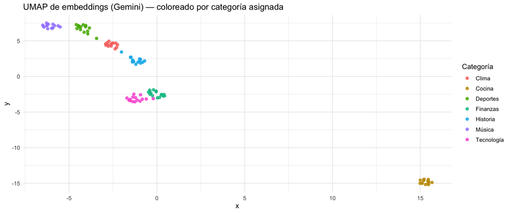

```r
# 4) UMAP (si existe el RDS)
if (file.exists(umap_rds)) {
  emb_2d <- readRDS(umap_rds)
  if (nrow(emb_2d) == nrow(df_gemini)) {
    df_plot <- df_gemini %>%
      mutate(x = emb_2d[,1], y = emb_2d[,2])

    p <- ggplot(df_plot, aes(x, y, color = categoria_gem)) +
      geom_point(alpha = 0.85, size = 2) +
      labs(title = "UMAP de embeddings (Gemini) — coloreado por categoría asignada",
           color = "Categoría") +
      theme_minimal(base_size = 12) +
      theme(legend.position = "right")
    print(p)
  } else {
    cat("**Aviso:** El UMAP guardado no coincide en filas con el CSV actual; omito el gráfico.\n")
  }
} else {
  cat("**Aviso:** No se encontró 'outputs/gemini_emb_2d.rds'. El UMAP se omite en el knit.\n")
}
```

### Conclusión — Gemini

En comparación con BERT y Qwen, Gemini ofrece una mayor capacidad de discriminación semántica, mostrando clusters más compactos y separados en el espacio reducido por UMAP.

# 7. Comparativa final de modelos LLM (BERT · Qwen3 · Gemini)

En este apartado integramos los resultados obtenidos con los tres enfoques de embeddings y clustering, comparando su calidad (Silhouette), la distribución de documentos por categoría y ejemplos de asignación, con el fin de evaluar fortalezas y debilidades de cada modelo.

```r
# --- 7) Comparativa final (BERT vs Qwen vs Gemini) desde CSV guardados (versión robusta) ---


# Helper para elegir la primera columna existente de un vector de posibles nombres
pick_col <- function(df, candidates) {
  hit <- intersect(candidates, names(df))
  if (length(hit) == 0) return(NULL)
  df[[hit[1]]]
}

# 1) Cargar CSVs (ajusta rutas si fuese necesario)
path_bert   <- "outputs/documentos_bert_clusters.csv"
path_qwen   <- "outputs/documentos_qwen_clusters.csv"
path_gemini <- "outputs/documentos_gemini_clusters.csv"

stopifnot(file.exists(path_bert), file.exists(path_qwen), file.exists(path_gemini))

bert   <- read_csv(path_bert,   show_col_types = FALSE)
qwen   <- read_csv(path_qwen,   show_col_types = FALSE)
gemini <- read_csv(path_gemini, show_col_types = FALSE)

# 2) Armonizar data frames a un esquema común: doc_id, texto, categoría
norm_df <- function(df, method) {
  tibble(
    doc_id = pick_col(df, c("doc_id","id","docID")),
    texto  = pick_col(df, c("texto","text","summary")),
    categoria = dplyr::coalesce(
      pick_col(df, c("categoria_bert","categoria_qwen","categoria_gem","categoria_gemini","categoria")),
      NA_character_
    ),
    metodo = method
  )
}

bert_n   <- norm_df(bert,   "BERT")
qwen_n   <- norm_df(qwen,   "Qwen3")
gemini_n <- norm_df(gemini, "Gemini")

# 3) Unir por doc_id
comp <- bert_n %>%
  select(doc_id, texto, cat_bert = categoria) %>%
  full_join(select(qwen_n,   doc_id, cat_qwen = categoria),   by = "doc_id") %>%
  full_join(select(gemini_n, doc_id, cat_gemini = categoria), by = "doc_id") %>%
  # ordenar por el número en doc_id si existe (doc_1, doc_2, …)
  mutate(doc_num = suppressWarnings(as.integer(str_extract(doc_id, "\\d+")))) %>%
  arrange(doc_num) %>%
  select(-doc_num)

# 4) Tabla comparativa principal
reactable(
  comp,
  searchable = TRUE, striped = TRUE, highlight = TRUE, pagination = TRUE,
  defaultPageSize = 15,
  columns = list(
    doc_id     = colDef(name = "Documento", width = 100),
    texto      = colDef(name = "Texto", minWidth = 520),
    cat_bert   = colDef(name = "BERT"),
    cat_qwen   = colDef(name = "Qwen3"),
    cat_gemini = colDef(name = "Gemini")
  ),
  theme = reactableTheme(headerStyle = list(fontWeight = 700))
)
```

| Documento | Texto | BERT | Qwen3 | Gemini |
| --- | --- | --- | --- | --- |
| doc_1 | Una suave brisa mecía las hojas mientras caminábamos por la orilla. | Clima | Clima | Clima |
| doc_2 | Las fuertes lluvias provocaron inundaciones en varios barrios bajos. | Clima | Clima | Clima |
| doc_3 | Hacía tanto calor que incluso los pájaros buscaban sombra bajo las palmeras. | Clima | Clima | Clima |
| doc_4 | El sol se asomaba entre las nubes tras una mañana lluviosa. | Clima | Clima | Clima |
| doc_5 | Las tormentas iluminaban el cielo con relámpagos. | Clima | Clima | Clima |
| doc_6 | Una espesa niebla se posaba sobre las calles de la ciudad al amanecer. | Clima | Clima | Clima |
| doc_7 | A medianoche, la temperatura había bajado por debajo del punto de congelación. | Clima | Clima | Clima |
| doc_8 | El aire olía a ozono tras la repentina granizada. | Clima | Clima | Clima |
| doc_9 | Las lecturas del barómetro indicaban la llegada de un frente. | Clima | Clima | Deportes |
| doc_10 | Una repentina ráfaga de viento derribó las sillas del jardín. | Clima | Clima | Clima |

[output cut: 96 more lines]

```r
# 5) Discrepancias: Gemini vs BERT y Gemini vs Qwen3
no_match_gem_bert <- comp %>% filter(!is.na(cat_gemini), !is.na(cat_bert),  cat_gemini != cat_bert)
no_match_gem_qwen <- comp %>% filter(!is.na(cat_gemini), !is.na(cat_qwen),  cat_gemini != cat_qwen)

if (nrow(no_match_gem_bert)) {
  cat("\n**No coinciden (Gemini ≠ BERT)**\n")
  print(reactable(
    no_match_gem_bert %>% select(doc_id, texto, BERT = cat_bert, Gemini = cat_gemini),
    searchable = TRUE, defaultPageSize = 10,
    columns = list(texto = colDef(minWidth = 520))
  ))
}
```

[output not shown]

```
##
## **No coinciden (Gemini ≠ BERT)**
```

```r
if (nrow(no_match_gem_qwen)) {
  cat("\n**No coinciden (Gemini ≠ Qwen3)**\n")
  print(reactable(
    no_match_gem_qwen %>% select(doc_id, texto, Qwen3 = cat_qwen, Gemini = cat_gemini),
    searchable = TRUE, defaultPageSize = 10,
    columns = list(texto = colDef(minWidth = 520))
  ))
}
```

[output not shown]

```
##
## **No coinciden (Gemini ≠ Qwen3)**
```

```r
# 6) Recuento por método y categoría
counts <- bind_rows(
  bert_n   %>% count(categoria, name = "n") %>% mutate(metodo = "BERT"),
  qwen_n   %>% count(categoria, name = "n") %>% mutate(metodo = "Qwen3"),
  gemini_n %>% count(categoria, name = "n") %>% mutate(metodo = "Gemini")
) %>%
  mutate(categoria = tidyr::replace_na(categoria, "(NA)")) %>%
  pivot_wider(names_from = metodo, values_from = n, values_fill = 0) %>%
  arrange(categoria) %>%
  rename(Categoría = categoria)

cat("\n**Recuento de documentos por categoría y método**\n")
```

```
##
## **Recuento de documentos por categoría y método**
```

```r
reactable(
  counts,
  defaultPageSize = 10, searchable = TRUE, striped = TRUE,
  theme = reactableTheme(headerStyle = list(fontWeight = 700))
)
```

| Categoría | BERT | Qwen3 | Gemini |
| --- | --- | --- | --- |
| Clima | 16 | 16 | 15 |
| Cocina | 15 | 15 | 15 |
| Deportes | 13 | 13 | 15 |
| Finanzas | 13 | 14 | 16 |
| Historia | 14 | 15 | 15 |
| Música | 16 | 16 | 15 |
| Tecnología | 19 | 17 | 15 |

```r
# --- 7) Comparativa entre BERT, Qwen3 y Gemini (desde CSV) con títulos integrados ---

instalar_si_falta("mclust")
instalar_si_falta("aricode")
instalar_si_falta("reactable")
instalar_si_falta("htmltools")

suppressPackageStartupMessages({
  library(dplyr); library(tidyr); library(readr); library(purrr)
  library(reactable); library(mclust); library(aricode); library(htmltools)
})

# Helper para poner título encima de cada reactable
rt_with_title <- function(tbl, title, ...) {
  tagList(
    htmltools::h4(title, style = "margin: 0 0 8px 0; font-weight: 700;"),
    reactable::reactable(tbl, ...)
  )
}

# Helper: elige el primer nombre que exista
pick_name <- function(nms, candidates, label="") {
  cn <- intersect(candidates, nms)
  if (length(cn) == 0) {
    stop(sprintf("No encuentro columna para %s. Candidatas: %s\nNombres presentes: %s",
                 label, paste(candidates, collapse=", "), paste(nms, collapse=", ")))
  }
  cn[1]
}

# 1) Cargar resultados
bert_raw <- read_csv("outputs/documentos_bert_clusters.csv", show_col_types = FALSE)
qwen_raw <- read_csv("outputs/documentos_qwen_clusters.csv", show_col_types = FALSE)
gem_raw  <- read_csv("outputs/documentos_gemini_clusters.csv", show_col_types = FALSE)

# 2) Normalizar nombres a un esquema común
# BERT
doc_id_col_b  <- pick_name(names(bert_raw), c("doc_id","Documento","id"), "doc_id (BERT)")
texto_col_b   <- pick_name(names(bert_raw), c("texto","Texto","text"), "texto (BERT)")
cat_col_b     <- pick_name(names(bert_raw), c("categoria_bert","categoria","categoria_asignada"), "categoría (BERT)")
bert <- bert_raw %>%
  transmute(doc_id = .data[[doc_id_col_b]],
            texto  = .data[[texto_col_b]],
            categoria_bert = .data[[cat_col_b]])

# Qwen3
doc_id_col_q  <- pick_name(names(qwen_raw), c("doc_id","Documento","id"), "doc_id (Qwen)")
cat_col_q     <- pick_name(names(qwen_raw), c("categoria_qwen","categoria","categoria_asignada"), "categoría (Qwen)")
qwen <- qwen_raw %>%
  transmute(doc_id = .data[[doc_id_col_q]],
            categoria_qwen = .data[[cat_col_q]])

# Gemini
doc_id_col_g  <- pick_name(names(gem_raw), c("doc_id","Documento","id"), "doc_id (Gemini)")
cat_col_g     <- pick_name(names(gem_raw), c("categoria_gem","categoria","categoria_asignada"), "categoría (Gemini)")
gem <- gem_raw %>%
  transmute(doc_id = .data[[doc_id_col_g]],
            categoria_gem = .data[[cat_col_g]])

# Unión
df <- bert %>% inner_join(qwen, by="doc_id") %>% inner_join(gem, by="doc_id")

# 3) Tasas de acuerdo (%) par a par
pct <- function(x) scales::percent(x, accuracy = 0.1)
agr_bq <- mean(df$categoria_bert == df$categoria_qwen)
agr_bg <- mean(df$categoria_bert == df$categoria_gem)
agr_qg <- mean(df$categoria_qwen == df$categoria_gem)
tasas <- tibble(
  Comparación = c("BERT vs Qwen3","BERT vs Gemini","Qwen3 vs Gemini"),
  `Acuerdo (%)` = pct(c(agr_bq, agr_bg, agr_qg))
)

# 4) ARI y NMI
asf <- function(x) as.factor(x)
ari_bq <- adjustedRandIndex(asf(df$categoria_bert), asf(df$categoria_qwen))
ari_bg <- adjustedRandIndex(asf(df$categoria_bert), asf(df$categoria_gem))
ari_qg <- adjustedRandIndex(asf(df$categoria_qwen), asf(df$categoria_gem))

nmi_bq <- NMI(df$categoria_bert, df$categoria_qwen)
nmi_bg <- NMI(df$categoria_bert, df$categoria_gem)
nmi_qg <- NMI(df$categoria_qwen, df$categoria_gem)

indices <- tibble(
  Comparación = c("BERT vs Qwen3","BERT vs Gemini","Qwen3 vs Gemini"),
  `ARI` = round(c(ari_bq, ari_bg, ari_qg), 3),
  `NMI` = round(c(nmi_bq, nmi_bg, nmi_qg), 3)
)

# 5) Matrices de confusión (BERT como referencia)
conf_bq <- df %>% count(Ref = categoria_bert, Qwen3 = categoria_qwen) %>% arrange(Ref, desc(n))
conf_bg <- df %>% count(Ref = categoria_bert, Gemini = categoria_gem)  %>% arrange(Ref, desc(n))

# 6) Acuerdo por categoría (acierto de Qwen/Gemini dentro de cada clase de referencia BERT)
acuerdo_por_cat <- df %>%
  mutate(OK_qwen = categoria_qwen == categoria_bert,
         OK_gem  = categoria_gem  == categoria_bert) %>%
  group_by(categoria_bert) %>%
  summarise(
    Docs = n(),
    `Qwen3 (acierto vs BERT)`  = pct(mean(OK_qwen)),
    `Gemini (acierto vs BERT)` = pct(mean(OK_gem)),
    .groups = "drop"
  ) %>%
  rename(Categoría = categoria_bert)

# 7) “Quién falla más” vs consenso (voto mayoritario con tie-break a BERT)
mayoria <- df %>%
  mutate(
    voto = pmap_chr(list(categoria_bert, categoria_qwen, categoria_gem), function(a,b,c){
      tab <- sort(table(c(a,b,c)), decreasing = TRUE)
      # si hay empate 1-1-1, desempatamos con BERT
      if (length(tab) == 3 && tab[1] == 1) return(a)
      names(tab)[1]
    }),
    fallo_bert = categoria_bert != voto,
    fallo_qwen = categoria_qwen != voto,
    fallo_gem  = categoria_gem  != voto
  )

quien_falla_mas <- tibble(
  Modelo = c("BERT","Qwen3","Gemini"),
  Fallos = c(sum(mayoria$fallo_bert), sum(mayoria$fallo_qwen), sum(mayoria$fallo_gem))
) %>%
  mutate(`% Fallos` = pct(Fallos / nrow(df)))

# 8) Tablas interactivas (con títulos integrados)
rt_with_title(
  tasas,
  title = "Tabla de acuerdos porcentuales entre modelos",
  theme = reactableTheme(headerStyle = list(fontWeight = "bold")),
  columns = list(Comparación = colDef(minWidth = 160))
)
```

#### Tabla de acuerdos porcentuales entre modelos

| Comparación | Acuerdo (%) |
| --- | --- |
| BERT vs Qwen3 | 96.2% |
| BERT vs Gemini | 94.3% |
| Qwen3 vs Gemini | 96.2% |

```r
rt_with_title(
  indices,
  title = "Tabla de índices ARI y NMI (medidas de similitud entre clusters)",
  theme = reactableTheme(headerStyle = list(fontWeight = "bold")),
  columns = list(Comparación = colDef(minWidth = 160))
)
```

#### Tabla de índices ARI y NMI (medidas de similitud entre clusters)

| Comparación | ARI | NMI |
| --- | --- | --- |
| BERT vs Qwen3 | 0.912 | 0.933 |
| BERT vs Gemini | 0.868 | 0.905 |
| Qwen3 vs Gemini | 0.912 | 0.934 |

```r
rt_with_title(
  conf_bq,
  title = "Correspondencia entre categorías de referencia (BERT) y las predicciones de Qwen3",
  groupBy = "Ref",
  searchable = TRUE,
  theme = reactableTheme(headerStyle = list(fontWeight = "bold")),
  columns = list(Ref = colDef(name="Ref (BERT)"), Qwen3 = colDef(name="Qwen3"))
)
```

#### Correspondencia entre categorías de referencia (BERT) y las predicciones de Qwen3

| Ref (BERT) | Qwen3 | n |
| --- | --- | --- |
| Clima | Clima | 16 |
| Cocina | Cocina | 15 |
| Deportes | Deportes | 13 |
| Finanzas | Finanzas | 12 |
| Finanzas | Tecnología | 1 |
| Historia | Historia | 14 |
| Música | Música | 16 |
| Tecnología | Tecnología | 16 |
| Tecnología | Finanzas | 2 |
| Tecnología | Historia | 1 |

```r
rt_with_title(
  conf_bg,
  title = "Correspondencia entre categorías de referencia (BERT) y las predicciones de Gemini",
  groupBy = "Ref",
  searchable = TRUE,
  theme = reactableTheme(headerStyle = list(fontWeight = "bold")),
  columns = list(Ref = colDef(name="Ref (BERT)"), Gemini = colDef(name="Gemini"))
)
```

#### Correspondencia entre categorías de referencia (BERT) y las predicciones de Gemini

| Ref (BERT) | Gemini | n |
| --- | --- | --- |
| Clima | Clima | 15 |
| Clima | Deportes | 1 |
| Cocina | Cocina | 15 |
| Deportes | Deportes | 13 |
| Finanzas | Finanzas | 13 |
| Historia | Historia | 14 |
| Música | Música | 15 |
| Música | Deportes | 1 |
| Tecnología | Tecnología | 15 |
| Tecnología | Finanzas | 3 |

[output cut: 1 more lines]

```r
rt_with_title(
  acuerdo_por_cat,
  title = "Exactitud por categoría frente a la referencia (BERT)",
  searchable = TRUE,
  theme = reactableTheme(headerStyle = list(fontWeight = "bold"))
)
```

#### Exactitud por categoría frente a la referencia (BERT)

| Categoría | Docs | Qwen3 (acierto vs BERT) | Gemini (acierto vs BERT) |
| --- | --- | --- | --- |
| Clima | 16 | 100.0% | 93.8% |
| Cocina | 15 | 100.0% | 100.0% |
| Deportes | 13 | 100.0% | 100.0% |
| Finanzas | 13 | 92.3% | 100.0% |
| Historia | 14 | 100.0% | 100.0% |
| Música | 16 | 100.0% | 93.8% |
| Tecnología | 19 | 84.2% | 78.9% |

```r
rt_with_title(
  quien_falla_mas,
  title = "Número de errores totales por modelo",
  defaultSorted = "Fallos", defaultSortOrder = "desc",
  theme = reactableTheme(headerStyle = list(fontWeight = "bold"))
)
```

#### Número de errores totales por modelo

| Modelo | Fallos | % Fallos |
| --- | --- | --- |
| BERT | 3 | 2.8% |
| Qwen3 | 1 | 0.9% |
| Gemini | 3 | 2.8% |

```r
# 9) Guardados
OUT <- "outputs"; dir.create(OUT, showWarnings = FALSE, recursive = TRUE)
write_csv(tasas, file.path(OUT,"tasas_acuerdo.csv"))
write_csv(indices, file.path(OUT,"indices_similitud.csv"))
write_csv(conf_bq, file.path(OUT,"confusion_BERT_vs_Qwen3.csv"))
write_csv(conf_bg, file.path(OUT,"confusion_BERT_vs_Gemini.csv"))
write_csv(acuerdo_por_cat, file.path(OUT,"acuerdo_por_categoria.csv"))
write_csv(quien_falla_mas, file.path(OUT,"fallos_vs_consenso.csv"))
```

## Conclusión general

En conjunto, los resultados reflejan que **los tres modelos son consistentes y robustos**, con una concordancia muy elevada. No obstante:  
- **Qwen3** se posiciona como el modelo más fiable en términos de menor tasa de error.  
- **Gemini** destaca en categorías como *Finanzas* y mantiene un rendimiento homogéneo.  
- **BERT**, aunque algo menos preciso en *Tecnología*, aporta estabilidad y sirve como buena referencia.

Estos hallazgos sugieren que, para aplicaciones prácticas, **la combinación de modelos (ensemble o validación cruzada entre ellos)** podría reforzar aún más la robustez de la clasificación en escenarios de auditoría documental.